# **Agenda**

# Quantitative plots

### histogram plot

- A histogram is the graphical representation of data where data is grouped into continuous number ranges and each range corresponds to a vertical bar

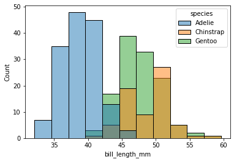

```python
sns.histplot(x="bill_length_mm",
            data=penguins,
            hue= "species")
```

**in histogram we have bins, binwidth and binrange so what are these and what are the difference**

- first, bins -------> it means the number of bars that are display so if i want to display 20 bar i will set bins = 20
- second, binwdth refers to the scale of each bin, if i want each bin scale 10 i will set binwidth = 10
- third, binrange it means the range that will display in histogram , if range is between 100 -200 and the data is between 10- 70 the histogram will not appear beacause he is out of the range

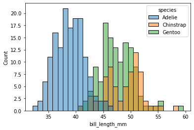

```python
#bins =30
sns.histplot(x="bill_length_mm",
            data=penguins,
            hue= "species",
            bins=30)
```

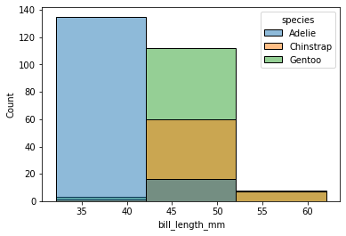

```python
# bin width = 10
sns.histplot(x="bill_length_mm",
            data=penguins,
            hue= "species",
            binwidth=10)
```

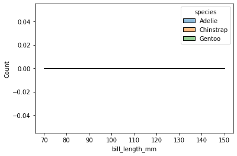

```python
# the histogram doesn't appear because he is out of range
sns.histplot(x="bill_length_mm",
            data=penguins,
            hue= "species",
            binrange=(70,150))
```

**we also can change the measure of histogram to be any measure as we like. using ------> stat**

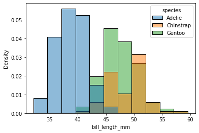

```python
sns.histplot(x="bill_length_mm",
            data=penguins,
            hue= "species",
            stat= "density")
```

**we can change the view of the histogram by using------> muliple it has options like {“layer”,“dodge”,“stack”,“fill”}**

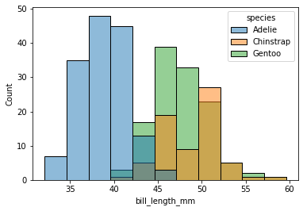

```python
sns.histplot(x="bill_length_mm",
            data=penguins,
            hue= "species",
            multiple="layer")
```

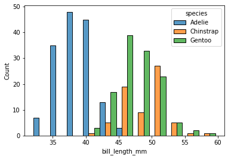

```python
sns.histplot(x="bill_length_mm",
            data=penguins,
            hue= "species",
            multiple="dodge")
```

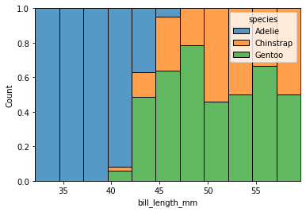

```python
sns.histplot(x="bill_length_mm",
            data=penguins,
            hue= "species",
            multiple="fill")
```

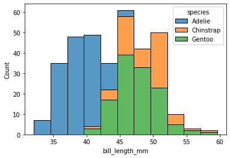

```python
sns.histplot(x="bill_length_mm",
            data=penguins,
            hue= "species",
            multiple="stack")
```

# Distributions plots

#### other polts are explained

### violin plot

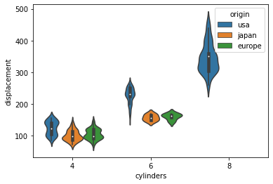

```python
#we will use cars data
sns.violinplot(x="cylinders",y="displacement",
              data=cars,
              hue="origin")
```

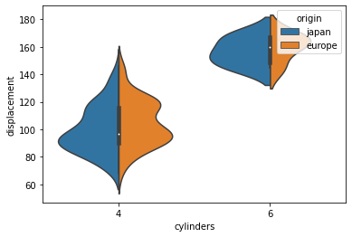

```python
# here we will change the measure using ------> scale
sns.violinplot(x='cylinders', y='displacement', hue='origin',
               data=cars[cars.origin.isin(['japan', 'europe'])],
               split=True,
               scale='count'
              )
```

# Relational plots

**we will use relplot to create the Relational plots**

- because it lets you create subplots in a single figure
- relpolt stands for relational plot

### scatter plot

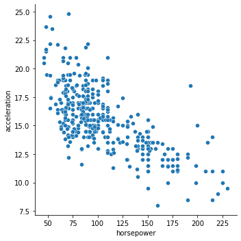

```python
sns.relplot(x= "horsepower",
           y="acceleration",
           data=cars,
           kind="scatter")
```

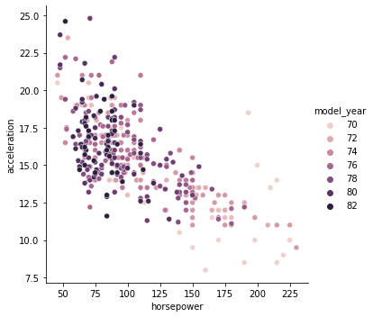

```python
# hue
sns.relplot(x= "horsepower",
           y="acceleration",
           data=cars,
           kind="scatter",
            hue="model_year")
```

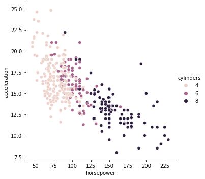

```python
# hue
sns.relplot(x= "horsepower",
           y="acceleration",
           data=cars,
           kind="scatter",
            hue="cylinders")
```

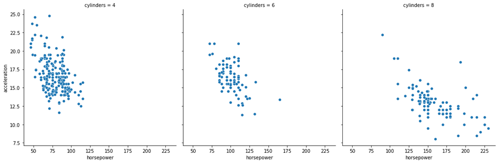

```python
# we can add col to make subscatter
sns.relplot(x= "horsepower",
           y="acceleration",
           data=cars,
           kind="scatter",
            col="cylinders")
```

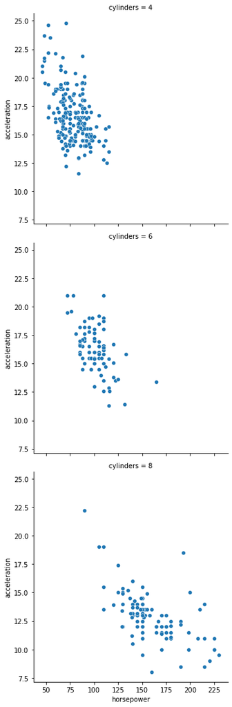

```python
# we can add row to make subscatter
sns.relplot(x= "horsepower",
           y="acceleration",
           data=cars,
           kind="scatter",
            row="cylinders")
```

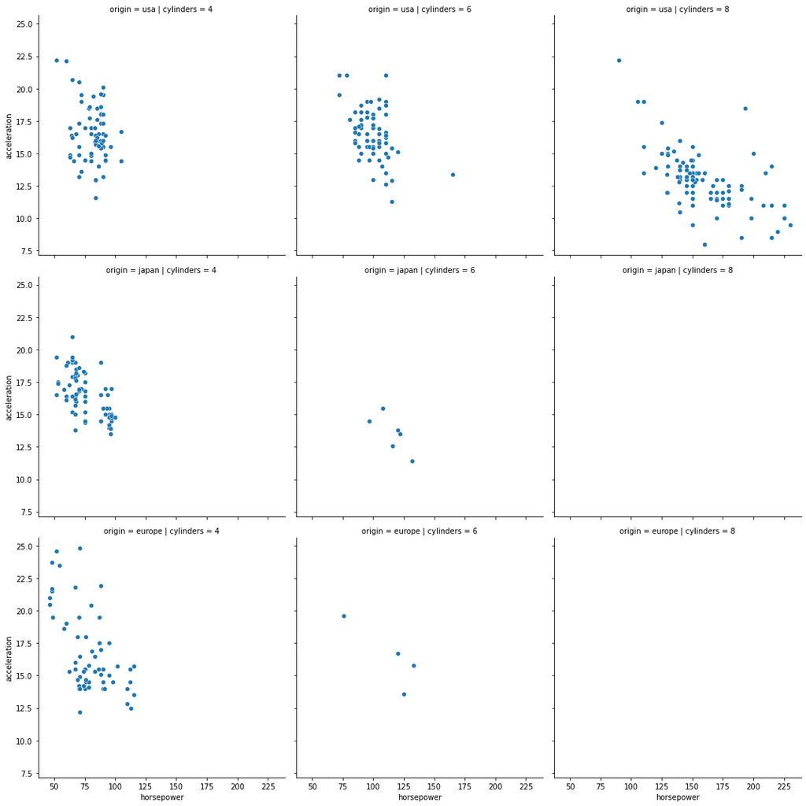

```python
# we can add col and row to make subscatter
sns.relplot(x= "horsepower",
           y="acceleration",
           data=cars,
           kind="scatter",
            col="cylinders",
           row="origin")
```

### Line plot

- Each plot point represents the same thing typically tracked over time
- Shaded region is the condence interval
- 95% condent that the mean is within this interval

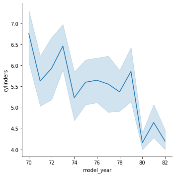

```python
sns.relplot(x="model_year",
           y="cylinders",
           data=cars,
           kind="line")
```

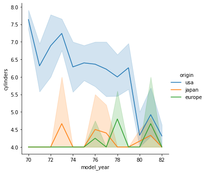

```python
sns.relplot(x="model_year",
           y="cylinders",
            hue="origin",
           data=cars,
           kind="line")
```

### heat map

- is a method of graphically representing numerical data where the value of each data point is indicated using colors

```python
cars.groupby('origin').cylinders.value_counts()
```

```
origin  cylinders
europe  4             61
        6              4
japan   4             69
        6              6
usa     8            103
        6             73
        4             69
Name: cylinders, dtype: int64
```

```python
origin_cyl = (
    cars
    .groupby('origin')
    .cylinders
    .value_counts()
    .unstack()
    .fillna(0)
)
```

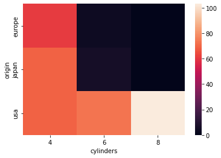

```python
sns.heatmap(origin_cyl)
```

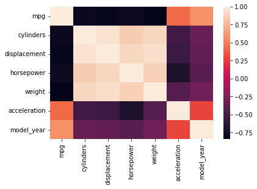

```python
sns.heatmap(cars.corr())
```

# Styling

### why styling ?

- Personal preference
- Improve readability
- Guide interpretation

#### Changing the figure style

- sns.set_style()
- it have five options [white,dark,whitegrid,darkgrid,ticks]

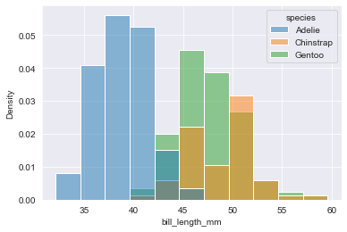

```python
sns.set_style("darkgrid")
sns.histplot(x="bill_length_mm",
            data=penguins,
            hue= "species",
            stat= "density")
```

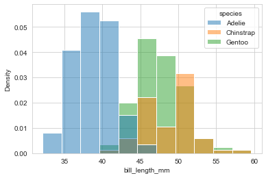

```python
sns.set_style("whitegrid")
sns.histplot(x="bill_length_mm",
            data=penguins,
            hue= "species",
            stat= "density")
```

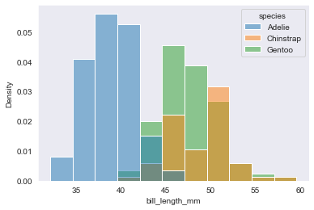

```python
sns.set_style("dark")
sns.histplot(x="bill_length_mm",
            data=penguins,
            hue= "species",
            stat= "density")
```

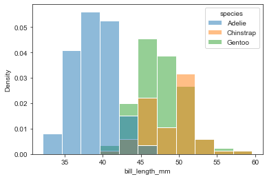

```python
sns.set_style("ticks")
sns.histplot(x="bill_length_mm",
            data=penguins,
            hue= "species",
            stat= "density")
```

- Figure "palette" changes the color of the main elements of the plot
- **sns.set_palette()**
- Use preset palettes or create a custom palette

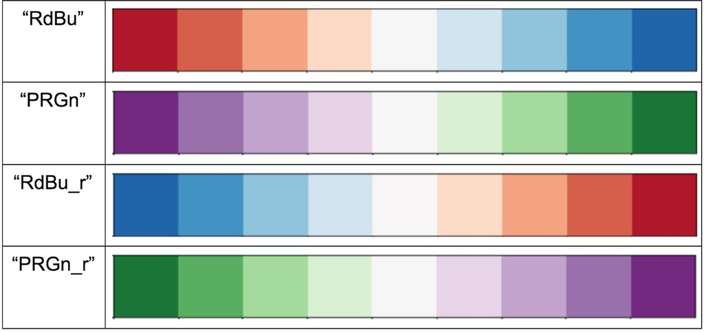

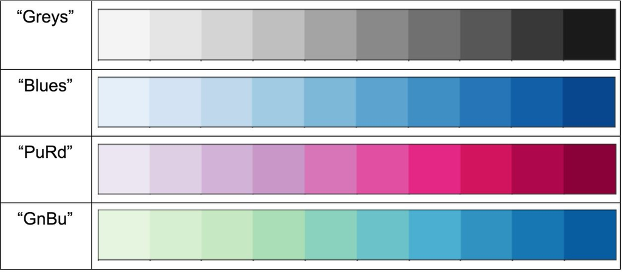

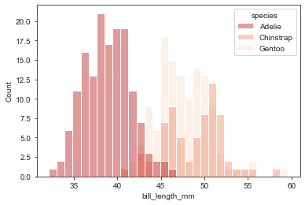

```python
sns.set_palette("RdBu")
sns.histplot(x="bill_length_mm",
            data=penguins,
              hue= "species",
            bins=30)
```

#### Changing the scale

- Figure "context" changes the scale of the plot elements andl abels
- sns.set_context()
- Smallest to largest :"paper","notebook","talk","poster"

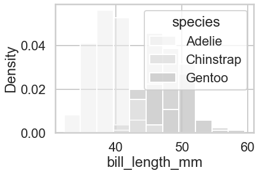

```python
sns.set_style("whitegrid")
sns.set_palette("Greys")
sns.set_context("poster")
sns.histplot(x="bill_length_mm",
            data=penguins,
            hue= "species",
            stat= "density")
```